# Unit 5 Homework

### W203 Statistics for Data Science

Student Name: Kevin Hartman

Section Number: 4

## Unladen Swallows

In the async lecture, we built a model consisting of two random variables: Let W represent the wingspan of a swallow, and V represents the velocity.

We assume W has a normal distribution with mean 10 and standard deviation 4.

We assume that $V = 0.5 \cdot W + U$, where $U$ is a random variable (which we might call error). We assume that $U$ has a standard normal distribution and is independent of $W$.

Using properties of variance and covariance, derive each element of the variance-covariance matrix for W and V.

**Givens**

> $\mu_w = 10 \quad \text{and} \quad \sigma_w = 4$

> The unladen swallow can be represented as a vector of random variables that are jointly distributed.

> $$\vec{S} = \begin{bmatrix} W \\ V \end{bmatrix}$$

> The variance-covariance matrix of $\vec{S}$ is described by

> $$Var(\vec{S}) = Var(W,V) = \begin{bmatrix} Var(W) & Cov(W,V) \\ Cov(V,W) & Var(V) \end{bmatrix}$$

**Answer**

Step 1. Calculate Var(W) >

> $Var(W) = \sigma_w^2 = 4^2 = 16$

> $$Var(\vec{S}) = \begin{bmatrix} 16 & Cov(W,V) \\ Cov(V,W) & Var(V) \end{bmatrix}$$

Step 2. Calculate Var(V) by substituting $V = 0.5W + U$ >

> $Var(V) = Var(0.5W + U)$

> Since U is independent of W, we can use $Var(X+Y) = Var(X) + Var(Y)$

> $\quad Var(V) = Var(0.5W) + Var(U)$

> Since U is a standard normal distribution with $\mu_u = 0 \text{ and } \sigma_u = 1 \text{, we know that } Var(U) = \sigma_u^2 = 1$

> $\quad Var(V) = Var(0.5W) + 1$

> $\quad Var(V) = E\big[(0.5W)^2\big] - \big[E(0.5W)\big]^2 + 1$

> $\quad Var(V) = E(0.25W^2) - \big[E(0.5W)\big]^2 + 1$

> $\quad Var(V) = 0.25E(W^2) - \big[0.5E(W)\big]^2 + 1$

> To find $E(W^2)$, we were given $\sigma_w = 4 \quad \text{ and } \quad Var(W) = 16 \quad and \quad \mu_w =E(W) = 10$

> $\quad Var(W) = E(W^2) - \big[E(W)\big]^2$

> $\quad 16 = E(W^2) - \big[10\big]^2$

> $\quad E(W^2) = 16 + \big[10\big]^2 = 116$

> Solving for Var(V) becomes

> $\quad Var(V) = 0.25(116) - \big[0.5 \cdot 10\big]^2 + 1$

> $\quad Var(V) = 29 - 5^2 + 1 = 29 - 25 + 1 = 5$

> $$Var(\vec{S}) = \begin{bmatrix} 16 & Cov(W,V) \\ Cov(V,W) & 5 \end{bmatrix}$$

Step 3. Calculate Cov(W,V) by substituting $V=0.5W + U$ >

> $Cov(W,V) = Cov(W,0.5W + U)$

> Since $Cov(X,Y+Z) = Cov(X,Y) + Cov(X,Z)$

> $\quad Cov(W,V) = Cov(W,0.5W) + Cov(W,U)$

> For $Cov(W,0.5W)$:

> $\quad Cov(W, 0.5W) = E\big[\big(W-\mu_w\big)\big(0.5W-0.5\mu_w\big)\big]$

> $\quad \quad = E\big[\big(W-\mu_w)\big)\cdot 0.5\big(W-\mu_w)\big)\big]$

> $\quad \quad = E\big[0.5\big(W-\mu_w)\big)^2\big]$

> $\quad \quad = 0.5E\big[\big(W-\mu_w\big)^2\big]$

> $\quad \quad = 0.5 \cdot Var(W)$

> $\quad \quad = 0.5 \cdot 16 = 8$

> For $Cov(W,U)$:

> $\quad Cov(W, U) = E\big[\big(W-\mu_w)\big)\big(U-\mu_u)\big)\big]$

> $\quad = E(WU) - \mu_w \mu_u$

> Since U and W are independent, $E(XY) = E(X) \cdot E(Y)$

> $\quad = E(W)E(U) - \mu_w \mu_u = 0$

> $\quad = \mu_w \mu_u - \mu_w \mu_u = 0$

> Finally,

> $\quad Cov(W,V) = Cov(W,0.5W + U) = Cov(W,0.5W) + Cov(W,U) = 8$

> And since Cov(X,Y) = Cov(Y,X),

> $\quad Cov(V,W)= 8$

> $$Var(\vec{S}) = \begin{bmatrix} 16 & 8 \\ 8 & 5 \end{bmatrix}$$

## Relating Min and Max

Continuous random variables $X$ and $Y$ have a joint distribution with probability density function,

$$ f(x,y) = \begin{cases} 2, &0 < y < x < 1 \\ 0, &otherwise. \end{cases} $$

You may wonder where you would find such a distribution. In fact, if $A_1$ and $A_2$ are independent random variables uniformly distributed on $[0,1]$, and you define $X = max(A_1,A_2)$, $Y = min(A_1,A_2)$, then $X$ and $Y$ will have exactly the joint distribution defined above.

a. Draw a graph of the region for which $X$ and $Y$ have positive probability density.

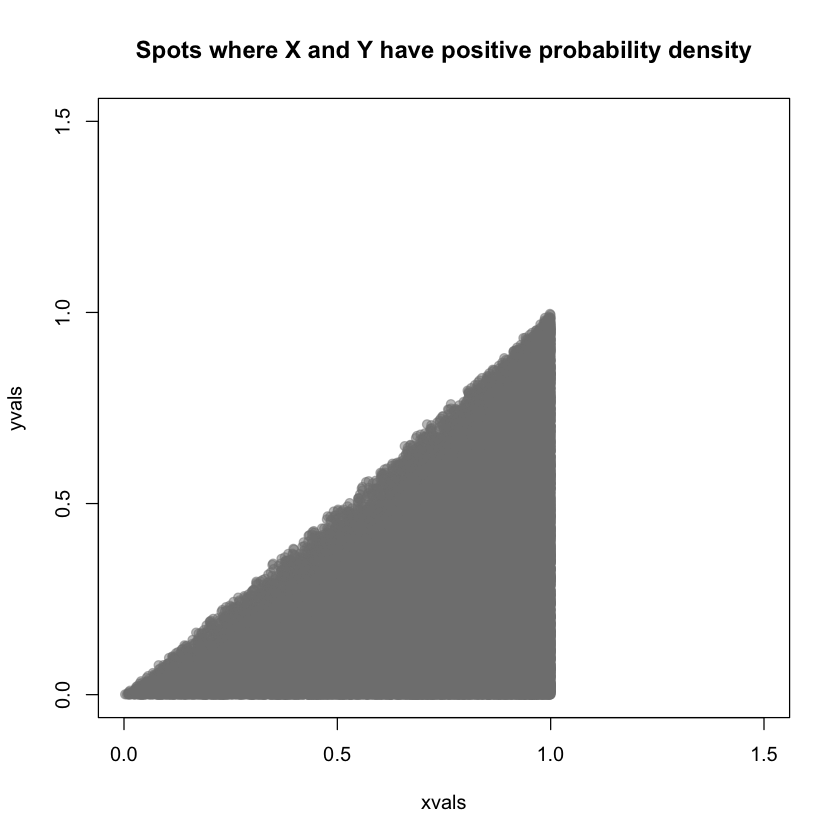

```r
set.seed(500)

n <- 100000
xvals <- as.numeric(NULL)
yvals <- as.numeric(NULL)
for(i in 1:n){
    ti <- runif(1, min=0, max=1)
    yvals[i] <- runif(1, min = 0, max = ti)
    xvals[i] <- runif(1, min = ti, max = 1)
}
plot(xvals, yvals, xlim = c(0,1.5), ylim = c(0,1.5), pch = 19, col = grey(0.5,0.5))
title("Spots where X and Y have positive probability density")
```

b. Derive the marginal probability density function of $X$, $f_X(x)$. Make sure you write down a complete expression.

**Answer**

> To find $f_X(x)$ we must integrate the function $f_{XY}(x,y)$ over all possible values y.

> $f_X(x) = \int\limits_{y=0}^x f_{XY}(x,y)dy \quad = \int\limits_{y=0}^x 2dy \quad = 2 y \big|_0^x \quad = 2x$

c. Derive the unconditional expectation of $X$.

**Answer**

> From the law of iterated expectation, $E(X) = E_Y[E(X|Y=y)]$

> $E[E(X|Y=y)] = \int\limits_{x=0}^1\int\limits_{y=0}^x f_{X}(x)dydx \quad = \int\limits_{x=0}^1\int\limits_{y=0}^x 2x dydx \quad = 2 \int\limits_{x=0}^1 x y\big|_0^x dx \quad = 2\int\limits_{x=0}^1 x^2dx = 2\frac{x}{3}\big|_0^1 = \frac{2}{3}$

d. Derive the conditional probability density function of $Y$, conditional on $X$, $f_{Y|X}(y|x)$

**Answer** >

> $f_{Y|X}(y|x) = P(Y=y|X=x) = \frac{f_{XY}(x, y)}{f_{X}(x)} \text{ for 0 < y < x}$

> $f_{Y|X}(y|x) = \frac{2}{2x} = \frac{1}{x}$

e. Derive the conditional expectation of $Y$, conditional on $X$, $E(Y|X)$.

**Answer** >

> $E(Y|X) = \int\limits_{y=0}^x y f_{Y|X}(y|x)dy \quad = \int\limits_{y=0}^x y \frac{1}{x}dy \quad = \frac{1}{x} \cdot \frac{y^2}{2}\big|_0^x \quad = \frac{x}{2}$

f. Derive $E(XY)$. Hint: if you take an expectation conditional on $X$, $X$ is just a constant inside the expectation. This means that $E(XY|X) = XE(Y|X)$.

**Answer** >

> $E(XY) = \int\limits_{x=0}^1 E[XY|X]f_X(x)dx \quad = \int\limits_{x=0}^1 XE[Y|X]f_X(x)dx = \int\limits_{x=0}^1 X \cdot \frac{x}{2} \cdot 2x dx = \frac{x^4}{4}\big|_0^1 = \frac{1}{4}$

g. Using the previous parts, derive $cov(X,Y)$

**Answer** >

> $Cov(X,Y) = E(XY) - E(X)E(Y)$

> $\quad = \frac{1}{4} - \frac{2}{3} \cdot E(Y)$

> $\quad = \frac{1}{4} - \frac{2}{3} \int\limits_{x=0}^{1} E(Y|X) f_X(x) dx$

> $\quad = \frac{1}{4} - \frac{2}{3} \int\limits_{x=0}^{1} \frac{x}{2} \cdot 2x dx$

> $\quad = \frac{1}{4} - \frac{2}{3} \cdot \frac{x^3}{3}\big|_0^1$

> $\quad = \frac{1}{4} - \frac{2}{3} \cdot \frac{1}{3}$

> $\quad = \frac{1}{4} - \frac{2}{9} = \frac{9}{36} - \frac{8}{36} = \frac{1}{36}$

## Great Time to Watch Async

Suppose your waiting time in minutes for the Caltrain in the morning is uniformly distributed on [0, 5], whereas waiting time in the evening is uniformly distributed on [0, 10]. Each waiting time is independent of all other waiting times.

**Givens** >

> $$\vec{M} = \begin{bmatrix} M_1 \\ M_2 \\ \vdots \\ M_5 \end{bmatrix} \quad \vec{N} = \begin{bmatrix} N_1 \\ N_2 \\ \vdots \\ N_5 \end{bmatrix}$$

> $\vec{M}$ is uniformly distributed on [0,5] and $\vec{N}$ is uniformly distributed on [0,10]. $\vec{M}$ and $\vec{N}$ are independent variables.

a. If you take the Caltrain each morning and each evening for 5 days in a row, what is your total expected waiting time?

**Answer** >

> $E(\vec{M} + \vec{N}) = E(\vec{M}) + E(\vec{N}) \text { because they are independent}$

> $E(M_i) = \frac{5 - 0}{2} = 2.5 \text { because } \vec{M} \text{ is uniform }$

> $E(N_i) = \frac{10 - 0}{2} = 5 \text { because } \vec{N} \text{ is uniform }$

> Total expected wait time $E(\vec{M}) + E(\vec{N}) = \sum\limits_{i=0}^5 E(M_i) + \sum\limits_{i=0}^5 E(N_i) = 5 \cdot 2.5 + 5 \cdot 5 = 12.5 + 25 = 37.5$

b. What is the variance of your total waiting time?

**Answer** >

> $Var(\vec{M} + \vec{N}) = Var(\vec{M}) + Var(\vec{N}) + 2Cov(\vec{M},\vec{N})$

> Because they are independent, $2Cov(\vec{M},\vec{N}) =0$

> $Var(X) = E(X^2) - [E([X)]^2$

> And in a uniform distribution,

> $E(X) = \int_{-\infty}^{\infty}x \cdot f(x)dx = \int_{A}^{B}x \cdot \frac{1}{B-A}dx$ \ $= \frac{x^2}{2\cdot(B-A)}\bigg\rvert_{A}^{B}=\frac{B^2-A^2}{2 \cdot(B-A)} = \frac{A+B}{2}$

> $[E([X)]^2 = \int_{-\infty}^{\infty}x^2 \cdot f(x)dx = \int_{A}^{B}x^2 \cdot \frac{1}{B-A}dx$ \ $= \frac{x^3}{3\cdot(B-A)}\bigg\rvert_{A}^{B}=\frac{B^3-A^3}{3 \cdot(B-A)} = \frac{A^2+2AB+B^2}{3}$

> $Var(X) = \frac{A^2+2AB+B^2}{3} - (\frac{A+B}{2})^2 = \frac{A^2+2AB+B^2}{3} - \frac{A^2+2AB+B^2}{4}$ $= \frac{A^2-2AB+B^2}{12} = \frac{(B-A)^2}{12}$

> Thus,

> $Var(M_i) = \frac{(5-0)^2}{12} = \frac{25}{12} \text { because } \vec{M} \text{ is uniform }$

> $Var(N_i) = \frac{(10-0)^2}{12} = \frac{100}{12} \text { because } \vec{M} \text{ is uniform }$

> Variance of total wait time $Var(\vec{M}) + Var(\vec{N}) = \sum\limits_{i=0}^5 Var(M_i) + \sum\limits_{i=0}^5 Var(N_i) = 5 \cdot \frac{25}{12} + 5 \cdot \frac{100}{12} = \frac{125}{12} + \frac{500}{12} = \frac{625}{12}$

c. What is the expected value of the difference between the total evening waiting time and the total morning waiting time over all 5 days?

**Answer** >

> Total expected difference between evening and morning $E(\vec{N}) - E(\vec{M}) = 25 - 12.5 = 12.5$

d. What is the variance of the difference between the total evening waiting time and the total morning waiting time over all 5 days?

**Answer** >

> $Var(\vec{M} - \vec{N}) = Var(\vec{M}) + Var(\vec{N}) - 2Cov(\vec{M},\vec{N})$

> Because they are independent, $2Cov(\vec{M},\vec{N}) =0$

> Variance of the difference between total wait times $Var(\vec{N}) + Var(\vec{M}) = \frac{625}{12}$

## Maximizing Correlation

Show that if $Y = aX + b$ where $X$ and $Y$ are random variables and $a \neq 0$, $corr(X,Y) = -1$ or $+1$.

**Answer** >

> $\rho = \rho_{X,Y} = Corr(X,Y) = \frac{Cov(X,Y)}{\sqrt{Var(X)Var(Y)}}$

> $Cov(X,Y) = Cov(X,aX+b) = E[X \cdot (aX+b)] - E(X) \cdot E(aX+b) = E[aX^2+bX] - E(X) \cdot aE(X) - E(X) \cdot E(b) = aE(X^2)+bE(X) - aE(X)^2-bE(X) = a[E(X^2) - E(X)^2] = a \cdot Var(X)$

> $Var(Y) = Var(aX+b) = a^2 \cdot Var(X)$

> $Corr(X,aX+b) = \frac{a \cdot Var(X)}{\sqrt{Var(X)a^2 \cdot Var(X)}} = \frac{a \cdot Var(X)}{\sqrt{a^2 \cdot Var(X)^2}} = \frac{a}{\sqrt{a^2}} = \left\{\begin{array}{rcl} +1; & a>1 \\ -1; & a<1 \end{array} \right.$

## Optional Challenge Problem: Working with Poisson Variables

A Poisson random variable $M$ is a discrete random variable with probability mass function given by

$$ P_M(m)= \frac{\alpha^m}{m!} e^{-\alpha}, m = 0,1,2,... $$

Where $\alpha$ is a parameter.

Let $N$ be another random variable that, conditional on $M=m$, is equally likely to take on any value in the set ${0,1,2,...,m}$

a. Find the joint PMF of $M$ and $N$

b. Find the marginal PMF of $N$, $P_N(n)$

c. Explain the significance of $N$ in terms of a Poisson process.